# R Notebook

# Contents

## PACF to estimate the order of AR(p) processes

> A moving average process of order q has an ACF that cuts off after q lags.

So, if you have an MA() process with enough terms that you believe the ACF is well estimated, and the ACF cuts off after 4 lags, you can be reasonably sure you have an MA(4) process. How about an AR(p) process? That is, if you know you have an AR(p) process, can you tell what the order of the process is?

We will see that the Partial Autocorrelation Function, or PACF will help us to find the order of an AR(p) process.

First, let’s create some data and look at some pictures.

```r
rm( list=ls( all = TRUE ) )
par(mfrow=c(3,1))
phi.1 = .6; phi.2 = .2
data.ts = arima.sim(n = 500, list(ar = c(phi.1, phi.2)))
plot(data.ts, main = paste("Autoregressive Process with phi1=",phi.1," phi2=",phi.2) )
acf(data.ts, main="Autocorrelation Function")
```

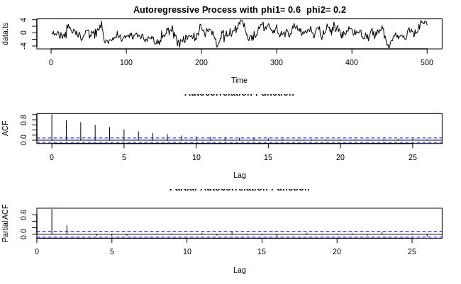

```r
acf(data.ts, type="partial", main="Partial Autocorrelation Function")
```

```r
rm( list=ls( all = TRUE ) )
par(mfrow=c(3,1))
phi.1 = .9; phi.2 = -.6; phi.3 = .3
data.ts = arima.sim(n = 500, list(ar = c(phi.1, phi.2, phi.3)))
plot(data.ts, main = paste("Autoregressive Process with phi1=", phi.1," phi2=",phi.2," phi3=",phi.3) )
acf(data.ts, main="Autocorrelation Function")
```

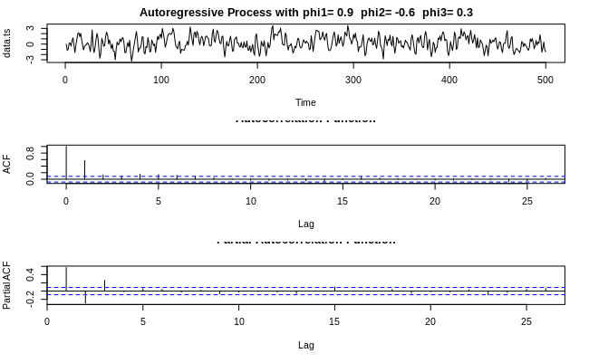

```r
acf(data.ts, type="partial", main="Partial Autocorrelation Function")
```

```r
phi.1 = .9; phi.2 = -.6;
par(mfrow=c(3,1))
data.ts = arima.sim(n = 500, list(ar = c(phi.1, phi.2)))
plot(data.ts,
main =
paste("Autoregressive Process with phi1=", phi.1," phi2=",phi.2 ) )
acf(data.ts)
```

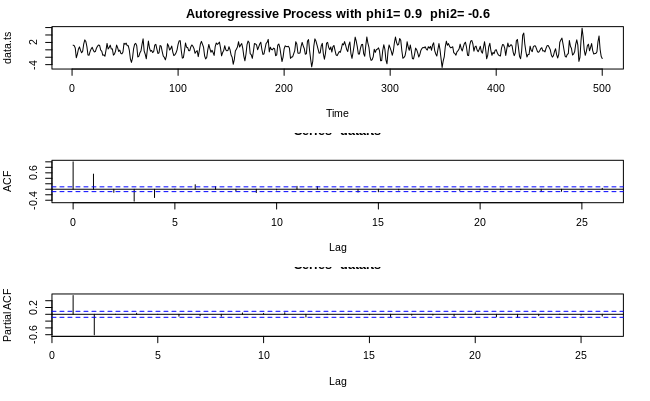

```r
acf(data.ts, type="partial")
```

#### Partial Autocorrelation Function and the Beveridge Wheat Price Data Set

(https://www.qlik.com/us/products/qlik-data-market?q=provider:tsdl)

```r
library(tseries)
```

```r
data(package="tseries")
```

```r
data(bev, package="tseries")
```

```r
ls()
```

```
[1] "bev"     "data.ts" "phi.1"   "phi.2"   "phi.3"
```

```r
help(bev)
```

```r
class(bev)
```

```
[1] "ts"
```

Create a “filter” with the simple moving average that uses 15 data points on either side of a given year to introduce some smoothing. Then plot the original series and the smoothed series on the same axes.

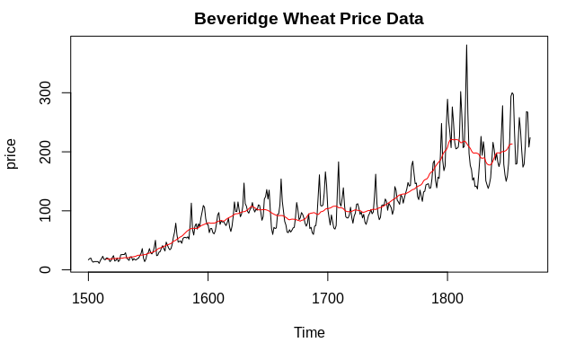

```r
beveridge.ts = bev
plot( beveridge.ts, ylab="price", main="Beveridge Wheat Price Data")
beveridge.MA = filter(beveridge.ts, rep(1/31, 31), sides = 2)
lines(beveridge.MA, col="red")
```

The acf() function doesn’t like missing data, so the first and last 15 numbers are ignored or omitted with the clean-up function na.omit().

```r
par(mfrow=c(3,1))
Y = beveridge.ts/beveridge.MA
plot( Y, ylab="scaled price", main="Transformed Beveridge Wheat Price Data")
acf(na.omit(Y),
main="Autocorrelation Function of Transformed Beveridge Data")
```

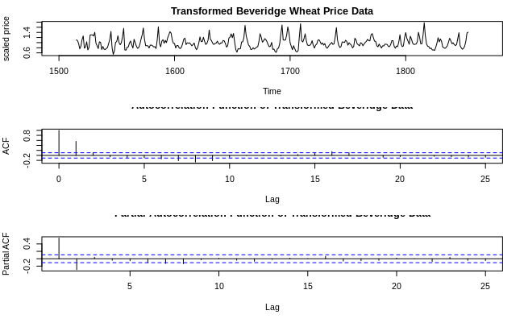

```r
acf(na.omit(Y), type="partial",
main="Partial Autocorrelation Function of Transformed Beveridge Data")
```

We will use the routine ar() to estimate the coefficients of our model. If we will allow up to 5 terms in our model (a reasonable number) we call

```r
ar(na.omit(Y), order.max = 5)
```

```
Call:
ar(x = na.omit(Y), order.max = 5)

Coefficients:
      1        2
 0.7239  -0.2957

Order selected 2  sigma^2 estimated as  0.02692
```

Just to state the obvious at this point:

> An autoregressive process of order p, an AR(p), has a PACF that cuts off after p lags.

we define a partial autocorrelation function $𝜙_{ℎℎ} ≡ 𝑐𝑜𝑟𝑟[𝑥_{𝑡+ℎ} − 𝑥̂_{𝑡+ℎ}, 𝑥_{𝑡} − 𝑥̂_{𝑡}]$

The paritial correlation coefficient is $𝑐𝑜𝑟𝑟[𝑥_{𝑡+ℎ} − 𝑥̂_{𝑡+ℎ}, 𝑥_{𝑡} − 𝑥̂_{𝑡}]$

We can calculate (estimate, really) these quantities from a given time series and have another plot to use in our quest to understand the stochastic process that generated the data at hand. We will plot the Partial Auto Correlation Function (PACF). The call in R is simple, we just give an argument to the acf() routine.

> acf(ts, type=“partial”)

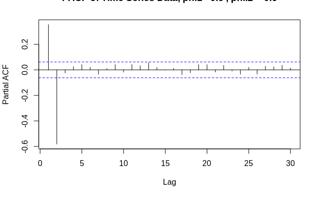

```r
phi.1 = .6;
phi.2 = -.6;
data.ts = arima.sim(n = 1000, list(ar = c(phi.1, phi.2)))
acf(data.ts, type="partial",
main=paste("PACF of Time Series Data, phi1=",phi.1,", phi.2=",phi.2) )
```

The excess correlation at 𝑙𝑎𝑔 = 𝑘 not accounted for by a (𝑘 − 1)𝑠𝑡 order model, is the partial correlation at lag=k

## AR processes - Examples

#### Hints: